# CIS242_HW2_Shuyue_Yang

## CIS 242

## Spring 2022

## HOMEWORK ASSIGNMENT 2

Please compile your responses use markdown in your Jupyter notebook to answer the questions. If you prefer, you may also submit a Word or PDF document with the responses along the PDF or HTML version of the completed notebook.

Please include your last name in the file name so we don't get too many HTML pages with the same name.

#### Active notebooks (.ipynb files) or raw code (.py files) will NOT be accepted and no points will be given.

The code part of the files will not be graded, but they will be checked if necessary to verify your findings and recommendations. Point deductions may occur if there are major discrepancies between your written answers and the output from the code. You are not required to comment your code but you will be happier later if you do.

Please organize your notebook to have the homework responses at the top and the working code underneath.

Each question is worth 2 points for a total of **16 points**.

#### The assignment is due at midnight on February 1st. Assignments submitted after that will lose 50% of the grade. Assignments submitted after midnight on February 8th will not be accepted.

Note: There is no single correct answer to these questions but there are wrong answers. You are welcome to collaborate on the code with other students but the explanations and answers must be in your own words.

Hint: focus on explaining what you did and why you did it. And always focus on content over technology.

- If the question asks about parameter settings, explain why you did (or did not) set them and why you chose the value that you did.
- If it asks you to explain the output, don't explain what the code did to produce that output but rather how we should understand what the output says.

We are always looking to be able to explain things to smart people who understand business issues but not necessarily how Python does things. Do not try to prove you listened to every word of lecture: including something that is incorrect will lose you points the same way not including something that is right will.

## Introducing Universal Bank

You were recently hired as a data scientist by Universal Bank. The bank’s Vice President is interested learning what predictive analytics can do for the bank. She supplies you with a dataset containing information on a sample of customers. Here is a description of each variable in the Universal Bank dataset:

- Age: Customer’s age in years
- Experience: Number of years of professional work experience
- Income: Annual income in thousands of dollars (\$000)
- Zip code: Zip code of home address
- Family: Customer’s family size
- CC Avg: Average spending on credit cards per month in thousands of dollars (\$000)
- Education: Education level where 1 = Undergraduate; 2 = Graduate; and 3=Advanced/Professional
- Mortgage: Value of house mortgage if any; in thousands of dollar (\$000)
- Personal.Loan: Did the customer accept a personal loan offered in the bank’s last campaign? 1=Yes; 0 = No.
- Securities.Account: Does the customer have a securities account with the bank? 1 = Yes; 0 = No.
- CD.Account: Does the customer have a certificate of deposit (CD) account with the bank? 1 = Yes; 0 = No.
- Online: Does the customer use Internet banking facilities? 1 = Yes; 0 = No.
- Credit.Card: Does the customer use a credit card issued by Universal Bank? 1 = Yes; 0 = No.

#### Name:

#### 1. Describe the content or the concepts in the dataset. List three relationships we might explore or questions might we be able to answer with the data.

```python
The dataset aims to find valuable bank customers based on the information of annual income, monthly spending, mortgage/loan debt, etc.
There is a positive linear relationship between customer's age and the number of years of professional work experience.
There is a positive linear relationship between customer's number of years of professional work experience and annual income.
There is a negative linear relationship between customer's age and average spending on credit cards per month.
```

```python
# code or markdown here
df.describe()
```

|  | Age | Experience | Income | ZIP Code | Family | CCAvg | Education | Mortgage | Personal Loan | Securities Account | CD Account | Online | CreditCard |
| --- | --- | --- | --- | --- | --- | --- | --- | --- | --- | --- | --- | --- | --- |
| count | 5000.000000 | 5000.000000 | 5000.000000 | 5000.000000 | 5000.000000 | 5000.000000 | 5000.000000 | 5000.000000 | 5000.000000 | 5000.000000 | 5000.00000 | 5000.000000 | 5000.000000 |
| mean | 45.338400 | 20.104600 | 73.774200 | 93152.503000 | 2.396400 | 1.937913 | 1.881000 | 56.498800 | 0.096000 | 0.104400 | 0.06040 | 0.596800 | 0.294000 |
| std | 11.463166 | 11.467954 | 46.033729 | 2121.852197 | 1.147663 | 1.747666 | 0.839869 | 101.713802 | 0.294621 | 0.305809 | 0.23825 | 0.490589 | 0.455637 |
| min | 23.000000 | -3.000000 | 8.000000 | 9307.000000 | 1.000000 | 0.000000 | 1.000000 | 0.000000 | 0.000000 | 0.000000 | 0.00000 | 0.000000 | 0.000000 |
| 25% | 35.000000 | 10.000000 | 39.000000 | 91911.000000 | 1.000000 | 0.700000 | 1.000000 | 0.000000 | 0.000000 | 0.000000 | 0.00000 | 0.000000 | 0.000000 |
| 50% | 45.000000 | 20.000000 | 64.000000 | 93437.000000 | 2.000000 | 1.500000 | 2.000000 | 0.000000 | 0.000000 | 0.000000 | 0.00000 | 1.000000 | 0.000000 |
| 75% | 55.000000 | 30.000000 | 98.000000 | 94608.000000 | 3.000000 | 2.500000 | 3.000000 | 101.000000 | 0.000000 | 0.000000 | 0.00000 | 1.000000 | 1.000000 |
| max | 67.000000 | 43.000000 | 224.000000 | 96651.000000 | 4.000000 | 10.000000 | 3.000000 | 635.000000 | 1.000000 | 1.000000 | 1.00000 | 1.000000 | 1.000000 |

#### 2. How would you describe the variables? What information can you provide about the values in the dataset?

```python
In the dataset, there are five dummy variables (Personal Loan, Securities Account, CD Account, Online, CreditCard).
When exploring these dummy variables, we cannot treat them with quantify analysis.
ZIP code as a categorical variable also can not be treated with quantify analysis, though it takes numerical values.
In addition, the values in the dataset need further data cleansing.
There is noisy data in 'ZIP Code' which has only 4 digits, while others are all 5 digits.
There are many negative values in 'Experience', but a negative number of years of professional work experience does not make sense.
```

```python
df.sort_values(by='ZIP Code',ascending=True)['ZIP Code']
```

```
384      9307
652     90005
1619    90005
1681    90005
4186    90005
        ...
3525    96651
1426    96651
2731    96651
672     96651
1653    96651
Name: ZIP Code, Length: 5000, dtype: int64
```

```python
df.sort_values(by='Experience',ascending=True)['Experience'].head(10)
```

```
4514   -3
2618   -3
4285   -3
3626   -3
3796   -2
2717   -2
4481   -2
3887   -2
2876   -2
2962   -2
Name: Experience, dtype: int64
```

#### 3. What relationships would you expect there to be between age and other variables? Why?

```python
Experience:
    Older people tend to have a greater number of years of professional work experience.
Income:
    Older people tend to have a higher average annual income since they have more work experience and reach a higher job position.
Zip code:
    No specific relationship. One zip code can have both expensive and cheap houses, so old and young people might live in the same area.
Family:
    Older people tend to have a larger family size since they might have children and even grandchildren.
CC Avg:
    Older people tend to spend less on credit cards since they do not shop much,
    while younger people might spend a lot.
Education:
    No specific relationship. Some older people might have advanced level since they have more time to pursue such degree,
    while others might only have undergraduate level due to previous backward education environment.
Mortgage:
    Older people tend to have less or no mortgage since they now have enough money to pay off the mortgage they had at a young age,
    while younger people still face the mortgage problem.
Personal.Loan:
    Older people tend to have fewer personal loans since they do not have financial difficulties,
    while younger people have fewer earnings and will accept a personal loan.
Securities.Account:
    No specific relationship since people can have securities accounts no matter what their age is.
CD.Account:
    Older people tend to have a CD account rather than young people since a CD account is a premium service and requires extra money.
    Older people can afford more on extra spending.
Online:
    Younger people tend to use Internet banking facilities rather than old people
    since older people might not know online technology as well as the younger ones.
Credit.Card:
    No specific relationship because people can have credit cards no matter what their age is.
```

#### 4. Do you find any evidence of those relationships? What is it and does it support your expectations?

```python
The scatter plot shows that there is a positive linear relationship between Age and Experience,
which supports my expectation of "Older people tend to have a greater number of years of professional work experience".
```

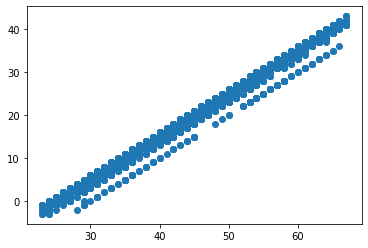

```python
# code or markdown here

plt.scatter(df['Age'],df['Experience'])
```

```python
The bar plot shows that 66 and 67-year-old people have the lowest average income,
which is quite different from what I expect of "Older people tend to have a higher average annual income".
```

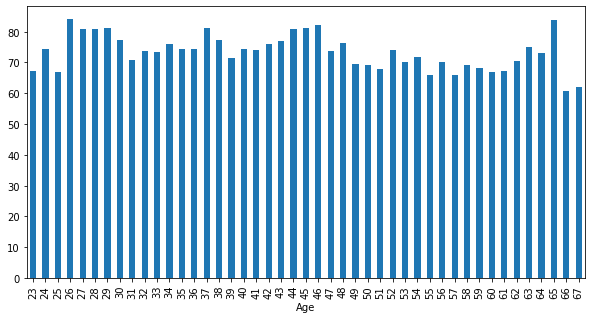

```python
# code or markdown here

income = df.groupby('Age')['Income'].agg(np.mean)
pd.DataFrame(income)
income.plot.bar(figsize=(10,5))
```

```python
The bar plot shows that there is a slightly negatively linear relationship between Age and CCAvg,
which supports my expectation of "Older people tend to spend less on credit cards, while younger people might spend a lot".
```

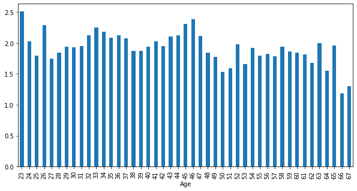

```python
# code or markdown here

ccavg = df.groupby('Age')['CCAvg'].agg(np.mean)
pd.DataFrame(ccavg)
ccavg.plot.bar(figsize=(10,5))
```